# Tef Project

First heatmap using native function, produces dendrogram and maps percentage identity, however, lacks y axis labels to demonstrate sequence comparison.

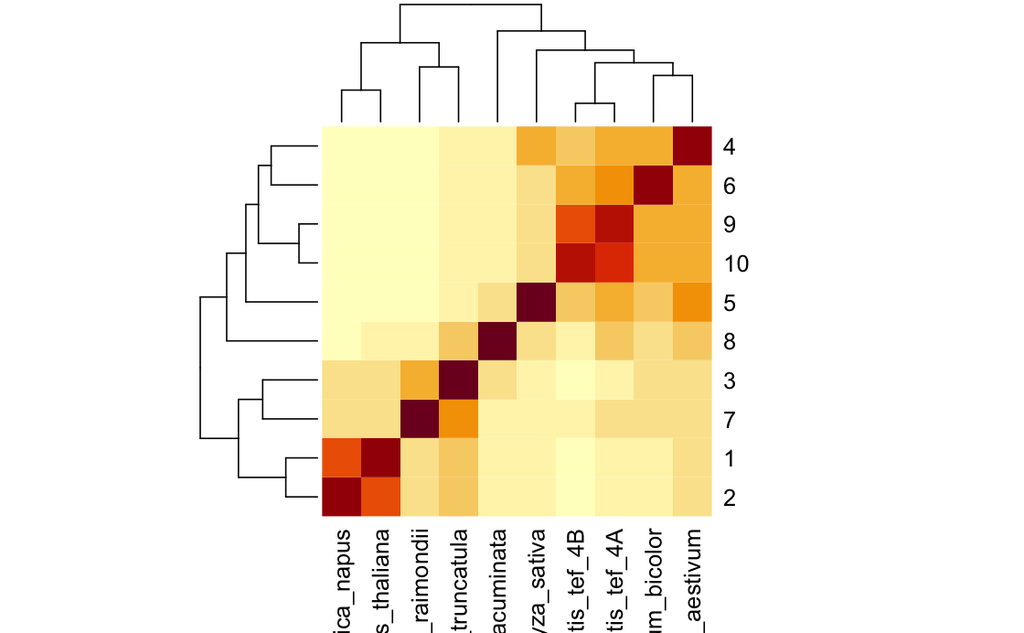

```r
#Establishes dataset and matrix in R environment
data = as.matrix(X_ID_Matrix)
heatmap(data)
```

Added y axis labels. However, native heatmap function lacks formatting complexity.

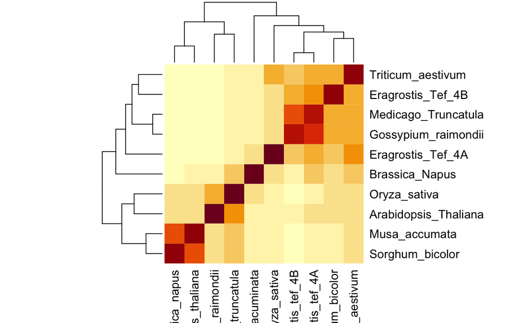

```r
#Establishes dataset as matrix in R environment
data = as.matrix(X_ID_Matrix)

#Setting row names to character values to show on heatmap
data_rows <- c("Musa_accumata",
               "Sorghum_bicolor",
               "Oryza_sativa",
               "Triticum_aestivum",
               "Eragrostis_Tef_4A",
               "Eragrostis_Tef_4B",
               "Arabidopsis_Thaliana",
               "Brassica_Napus",
               "Medicago_Truncatula",
               "Gossypium_raimondii"
               )
row.names(data) <- data_rows

heatmap(data)
```

Exploring ggplot heatmap function to draw, used GAI (CoPilot) to assist. Allows more customisation on formatting, however lacks dendrogram function which is particularly useful to the figure. When setting color scheme, we would aim to have the scale go from 0-100% rather than setting the midpoint to the median value in the dataset. GAI also decided that further manipulation of the matrix to long format was necessary for ggplot function, my previous experience with ggplot suggests this is the right move, however it may not be the most efficient. Ultimately, the efficiency of this chunk is irrelevant as no detail is lost by doing this, but it muddies the ease of interpreting the code.

```r
#Loading packages: ggplot for heatmap, tidyr and dplyr for dataset manipulation
library(ggplot2)
library(tidyr)
library(dplyr)

# Matrix and row names
data <- as.matrix(X_ID_Matrix)
data_rows <- c(
  "Musa_accumata",
  "Sorghum_bicolor",
  "Oryza_sativa",
  "Triticum_aestivum",
  "Eragrostis_Tef_4A", "Eragrostis_Tef_4B",
  "Arabidopsis_Thaliana",
  "Brassica_Napus",
  "Medicago_Truncatula",
  "Gossypium_raimondii"
)
rownames(data) <- data_rows

# Convert matrix to data frame with rownames as a column
df <- as.data.frame(data) %>%
  mutate(Species = rownames(data))

# Long formatting matrix to suit ggplot heatmap plotting
df_long <- df %>%
  pivot_longer(
    cols = -Species,
    names_to = "Comparative",
    values_to = "Value"
  )
#expressing df_long to check formatting
df_long
```

| Species | Comparative | Value |
| --- | --- | --- |
| Musa_accumata | Arabidopsis_thaliana | 100.00 |
| Musa_accumata | Brassica_napus | 80.63 |
| Musa_accumata | Medicago_truncatula | 59.76 |
| Musa_accumata | Triticum_aestivum | 54.33 |
| Musa_accumata | Oryza_sativa | 51.19 |
| Musa_accumata | Sorghum_bicolor | 49.93 |
| Musa_accumata | Gossypium_raimondii | 55.16 |
| Musa_accumata | Musa_acuminata | 50.14 |
| Musa_accumata | Eragrostis_tef_4A | 50.69 |
| Musa_accumata | Eragrostis_tef_4B | 45.12 |

[output cut: 90 more lines]

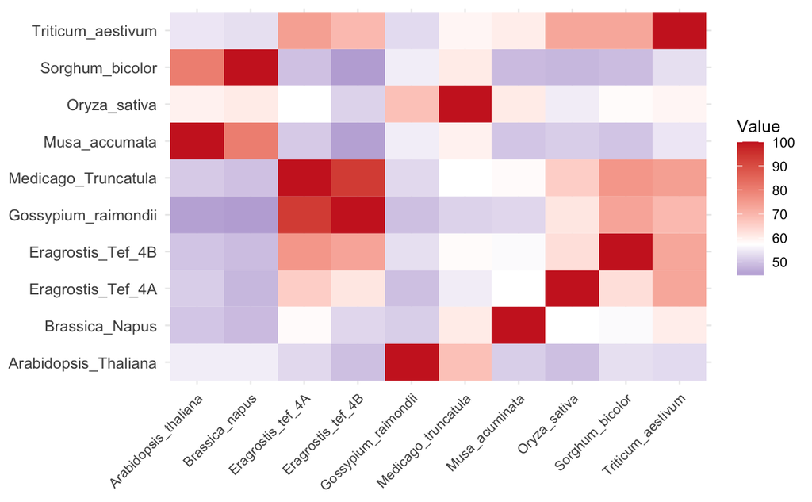

```r
# Heatmap generation
ggplot(df_long, #sets dataset
       aes(x = Comparative, y = Species, fill = Value)) + #sets aesthetics for plot
  geom_tile() + #sets style for geom_points to tiled
  scale_fill_gradient2(
    low = "navy",
    mid = "white",
    high = "firebrick3",
    midpoint = median(df_long$Value, na.rm = TRUE)
  ) + #Sets color scheme, midpoint function sets the median value of the data set to white
  theme_minimal() + #minimises formatting to clean up figure
  theme(
    axis.text.x = element_text(angle = 45, hjust = 1), #rotates x axis text for reading
    axis.text.y = element_text(size = 10), #setting text formatting
    axis.title.x = element_blank(), #removing axis titles, unnecessary for heatmap figure
    axis.title.y = element_blank()
  )
```

Now experimenting with pretty heatmaps package, this will allow custom formatting similar to ggplot, while bringing back the dendrogram function, as well as annotations which mean we can distinguish taxonomy of species within the figure. This chunk also only requires the pheatmap package, as all data manipulation is run through R native functions.

A key distinction that puts me in favour of this heatmap is the taxonomy annotations, this has been done manually, but it would be interesting to create an automated means to retrieve taxonomic data of ensembl plant entries - future project?…

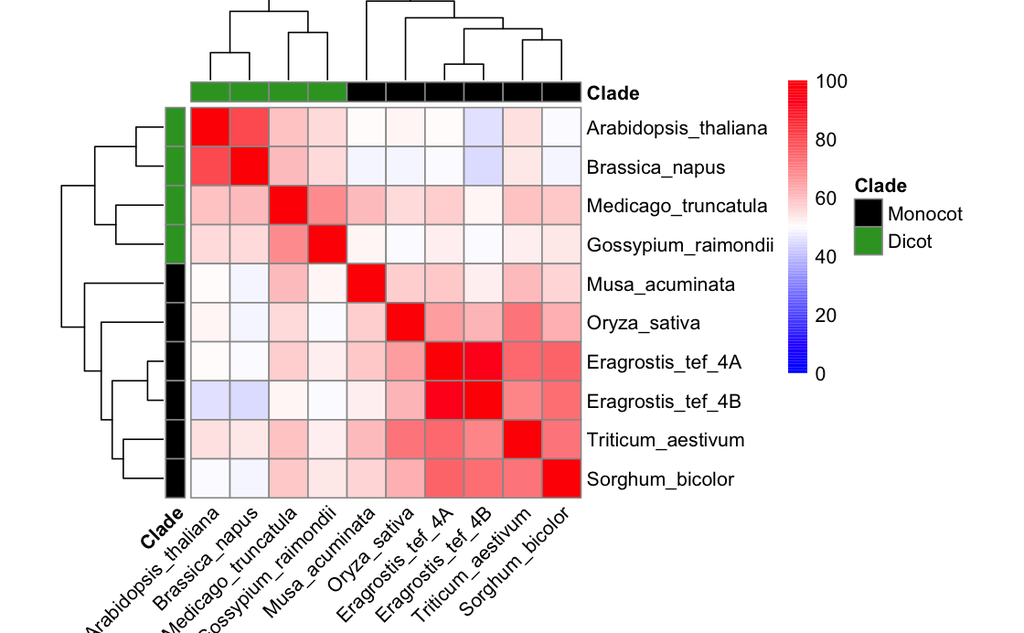

```r
#Loading pretty heatmaps (pheatmap) package
library(pheatmap)


# Matrix and row names
data <- as.matrix(X_ID_Matrix)
data_rows <- c(
  "Arabidopsis_thaliana",
  "Brassica_napus",
  "Medicago_truncatula",
  "Triticum_aestivum",
  "Oryza_sativa",
  "Sorghum_bicolor",
  "Gossypium_raimondii",
  "Musa_acuminata",
  "Eragrostis_tef_4A",
  "Eragrostis_tef_4B"
)
rownames(data) <- data_rows

#Setting colour scale for datapoints, (100) dictates a range that the colour gradient exists in
color = colorRampPalette(c("blue", "white", "red"))(100)

#Makes scale go from 0 to 100%, otherwise format would range between min and max values in matrix
breaks = c(0:100)


#Delineating the crops clade by creating a vector called clade_type with clade information, I have to assign these manually, would be good to have automated assignment
clade_type <- c(
  "Dicot",    # AT
  "Dicot",    # BN
  "Dicot",    # MT
  "Monocot",  # TA
  "Monocot",  # OS
  "Monocot",  # SB
  "Dicot",    # GR
  "Monocot",  # MA
  "Monocot",    # ET4A
  "Monocot"     # ET4B
)

#Creates annotations dataframe using the clade_type vector and column names from matrix
annotations <- data.frame(
  Clade = clade_type
)
row.names(annotations) <- colnames(data) #Assigns the clade to the annotations dataframe, using the column names of the matrix as a reference. This wouldn't work if the clade_type/matrix columns were reordered.

#Assigns clade value to a colour using annotation_crop_colors array
annotation_crop_colors <- list( Clade = c( Monocot = "black", # Black
                                          Dicot = "#33a02c" # green
))


#Producing heatmap
pheatmap(data, #Sets data for plot
         angle_col = 45, #Sets angle of column labels for readability
         color = color, #Sets color scheme of data points to pre-assigned palette variable
         breaks = breaks, #Sets breaks value to scale assigned as breaks variable
         annotation_col = annotations, #Sets column annotations to annotations dataframe
         annotation_row = annotations, #Sets row annotations to annotations dataframe
         annotation_colors = annotation_crop_colors, #Formats annotation colours to annotation_crop_colors array
         cluster_rows = TRUE, #Clusters rows, allows sensible dendrogram
         cluster_cols = TRUE, #Clusters columns, allows sensible dendrogram
         cellwidth = 20,
         cellheight = 20,
         legend = TRUE) #Produces legend to interpret figure
```

Going to create similar heatmap, displaying the percentage identity matrix of the amino acid sequence of the investigated genes. May reveal closer functional correlations of the gene.

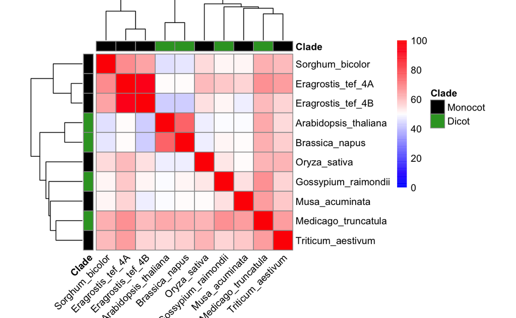

```r
#Loading pretty heatmaps (pheatmap) package
library(pheatmap)


# Matrix and addition of species row names
AAdata <- as.matrix(AA_ID_Matrix)
AAdata_rows <- c(
  "Arabidopsis_thaliana",
  "Brassica_napus",
  "Medicago_truncatula",
  "Triticum_aestivum",
  "Oryza_sativa",
  "Sorghum_bicolor",
  "Gossypium_raimondii",
  "Musa_acuminata",
  "Eragrostis_tef_4A",
  "Eragrostis_tef_4B"
)

rownames(AAdata) <- AAdata_rows

#Setting colour scale for datapoints, (100) dictates a range that the colour gradient exists in
color = colorRampPalette(c("blue", "white", "red"))(100)

#Makes scale go from 0 to 100%, otherwise format would range between min and max values in matrix
breaks = c(0:100)

#Delineating the crops clade by creating a vector called clade_type with clade information
AAclade_type <- c(
  "Dicot",    # AT
  "Dicot",    # BN
  "Dicot",    # MT
  "Monocot",  # TA
  "Monocot",  # OS
  "Monocot",  # SB
  "Dicot",    # GR
  "Monocot",  # MA
  "Monocot",  # ET4A
  "Monocot"   # ET4B
)

#Creates annotations dataframe using the clade_type vector and column names from matrix
AAannotations <- data.frame(
  Clade = AAclade_type
)
row.names(AAannotations) <- colnames(AAdata) #Assigns the clade to the annotations dataframe, using the column names of the matrix as a reference.

#Assigns clade value to a colour using annotation_crop_colors array
AAannotation_crop_colors <- list( Clade = c( Monocot = "black", # Black
                                          Dicot = "#33a02c" # green
))

#Producing heatmap
pheatmap(AAdata, #Sets data for plot
         angle_col = 45, #Sets angle of column labels for readability
         color = color, #Sets color scheme of data points to pre-assigned palette
         breaks = breaks, #Sets breaks value to scale assigned by breaks vector
         annotation_col = AAannotations, #Sets column annotations to annotations dataframe
         annotation_row = AAannotations, #Sets row annotations to annotations dataframe
         annotation_colors = AAannotation_crop_colors, #Formats annotation colours to annotation_crop_colors array
         cluster_rows = TRUE, #Clusters rows, allows sensible dendrogram
         cluster_cols = TRUE, #Clusters columns, allows sensible dendrogram
         cellwidth = 20,
         cellheight = 20,
         legend = TRUE) #Produces legend to interpret figure
```

Decided to create a similar heatmap using TM-score and alphafold. Uses buckets instead of gradient colour scheme.

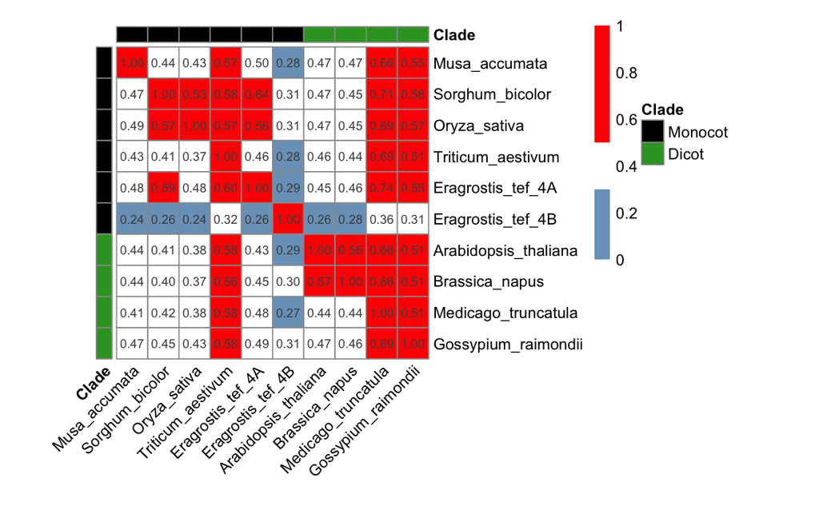

```r
library(pheatmap)
library(dplyr)


# Matrix and row names
fold_data <- as.matrix(TM_align_matrix)

fold_data_rows <- c(
  "Musa_accumata",
  "Sorghum_bicolor",
  "Oryza_sativa",
  "Triticum_aestivum",
  "Eragrostis_tef_4A",
  "Eragrostis_tef_4B",
  "Arabidopsis_thaliana",
  "Brassica_napus",
  "Medicago_truncatula",
  "Gossypium_raimondii"
)
#Applying species name to fold_data matrix
rownames(fold_data) <- fold_data_rows

#Colour scheme
breaks2 <- c(seq(0, 0.25, length.out = 26),
                    seq(0.25, 0.50, length.out = 26)[-1],
                    seq(0.50, 0.75, length.out = 26)[-1],
                    seq(0.75, 1.00, length.out = 26)[-1] )

breaks2 <- c(0, 0.3, 0.50, 1.00)

colors2 <- c(
  "#7AA2C4",      # bucket 1
  "white",     # bucket 2
  "red"        # bucket 3
)


#Delineating the crop types
fold_crop_type <- c(
  "Monocot",  # Musa_accuminata
  "Monocot",  # Sorghum_bicolor
  "Monocot",  # Oryza_sativa
  "Monocot",  # Triticum_aestivum
  "Monocot",  # Eragrostis_tef_4A
  "Monocot",  # Eragrostis_tef_4B
  "Dicot",    # Arabidopsis_thaliana
  "Dicot",    # Brassica_napus
  "Dicot",    # Medicago_truncatula
  "Dicot"     # Gossypium_raimondii
)

#Creating dataframe to apply annotations with colour against clade
fold_annotations <- data.frame(
  Clade = fold_crop_type
)
row.names(fold_annotations) <- colnames(fold_data)

#Creating colour scheme to apply to annotations later
fold_annotation_crop_colors <- list( Clade = c( Monocot = "black", # Black
                                          Dicot = "#33a02c" # green
))

#Heatmap
pheatmap(fold_data,
         angle_col = 45,
         color = colors2,
         breaks = breaks2,
         annotation_col = fold_annotations,
         annotation_row = fold_annotations,
         annotation_colors = fold_annotation_crop_colors,
         annotation_names_row = TRUE,
         annotation_names_col = TRUE,
         cluster_rows = FALSE,
         cluster_cols = FALSE,
         display_numbers = TRUE,
         cellwidth = 20,
         cellheight = 20,
         legend = TRUE)
```

```r
NA
NA
```